# 17_AROC_dimensions

## 17_AROC_dimensions

#### Question

1. In the table below, various physical quantities and some common units of measure are presented:

   | quantity | units of measure |
   | --- | --- |
   | time | seconds ($\mathrm{s}$) |
   | distance | meters ($\mathrm{m}$) |
   | velocity | meters per second ($\mathrm{m/s}$) |
   | acceleration | meters per squared second ($\mathrm{m/s^2}$) |
   | jerk | meters per cubed second ($\mathrm{m/s^3}$) |
   | force | Newtons ($\mathrm{N}$) |
   | impulse (momentum) | Newton-seconds ($\mathrm{N\cdot s}$) |
   | energy | Newton-meters ($\mathrm{N\cdot m}$) |
   | energy | Joules ($\mathrm{J}$) |
   | energy | kilowatt-hours ($\mathrm{kW\cdot hr}$) |
   | power | Newton-meters per second ($\mathrm{\frac{N\cdot m}{s}}$) |
   | power | Joules per second ($\mathrm{J/s}$) = Watts ($\mathrm{W}$) |
   | power | kilowatt ($\mathrm{kW}$) |
   | electrical charge | Coulombs ($\mathrm{C}$) |
   | electrical current | Coulombs/second ($\mathrm{C/s}$) = amperes ($\mathrm{A}$) |

   A device measures energy (in $\mathrm{N\cdot m}$) as a function of distance (in $\mathrm{m}$). Those measurements are graphed below.

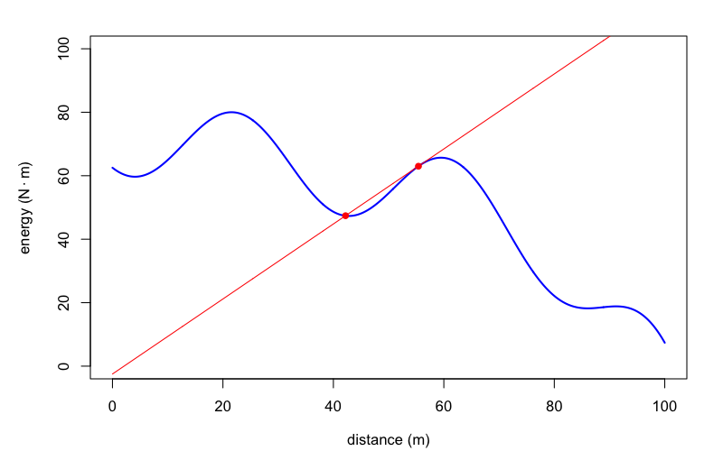

   The two marked points are at coordinates (42.2, 47.4) and (55.4, 63). Determine the average rate of change of the energy over the given interval of distance marked by the two points.

   AROC =

#### Question

2. In the table below, various physical quantities and some common units of measure are presented:

   | quantity | units of measure |
   | --- | --- |
   | time | seconds ($\mathrm{s}$) |
   | distance | meters ($\mathrm{m}$) |
   | velocity | meters per second ($\mathrm{m/s}$) |
   | acceleration | meters per squared second ($\mathrm{m/s^2}$) |
   | jerk | meters per cubed second ($\mathrm{m/s^3}$) |
   | force | Newtons ($\mathrm{N}$) |
   | impulse (momentum) | Newton-seconds ($\mathrm{N\cdot s}$) |
   | energy | Newton-meters ($\mathrm{N\cdot m}$) |
   | energy | Joules ($\mathrm{J}$) |
   | energy | kilowatt-hours ($\mathrm{kW\cdot hr}$) |
   | power | Newton-meters per second ($\mathrm{\frac{N\cdot m}{s}}$) |
   | power | Joules per second ($\mathrm{J/s}$) = Watts ($\mathrm{W}$) |
   | power | kilowatt ($\mathrm{kW}$) |
   | electrical charge | Coulombs ($\mathrm{C}$) |
   | electrical current | Coulombs/second ($\mathrm{C/s}$) = amperes ($\mathrm{A}$) |

   A device measures impulse (in $\mathrm{N\cdot s}$) as a function of time (in $\mathrm{s}$). Those measurements are graphed below.

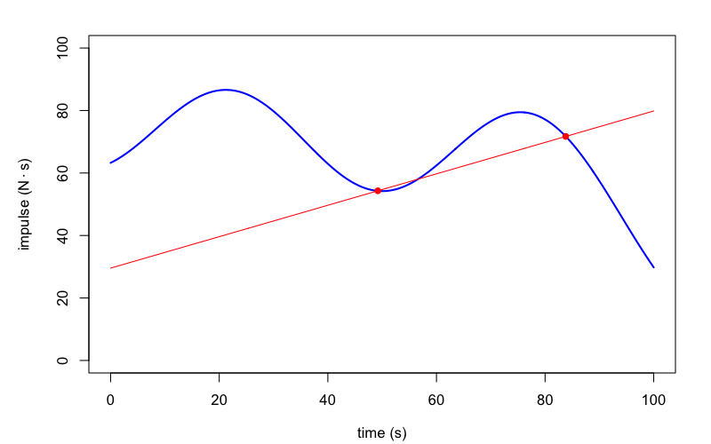

   The two marked points are at coordinates (49.2, 54.3) and (83.8, 71.7). Determine the average rate of change of the impulse over the given interval of time marked by the two points.

   AROC =

#### Question

3. In the table below, various physical quantities and some common units of measure are presented:

   | quantity | units of measure |
   | --- | --- |
   | time | seconds ($\mathrm{s}$) |
   | distance | meters ($\mathrm{m}$) |
   | velocity | meters per second ($\mathrm{m/s}$) |
   | acceleration | meters per squared second ($\mathrm{m/s^2}$) |
   | jerk | meters per cubed second ($\mathrm{m/s^3}$) |
   | force | Newtons ($\mathrm{N}$) |
   | impulse (momentum) | Newton-seconds ($\mathrm{N\cdot s}$) |
   | energy | Newton-meters ($\mathrm{N\cdot m}$) |
   | energy | Joules ($\mathrm{J}$) |
   | energy | kilowatt-hours ($\mathrm{kW\cdot hr}$) |
   | power | Newton-meters per second ($\mathrm{\frac{N\cdot m}{s}}$) |
   | power | Joules per second ($\mathrm{J/s}$) = Watts ($\mathrm{W}$) |
   | power | kilowatt ($\mathrm{kW}$) |
   | electrical charge | Coulombs ($\mathrm{C}$) |
   | electrical current | Coulombs/second ($\mathrm{C/s}$) = amperes ($\mathrm{A}$) |

   A device measures energy (in $\mathrm{kW\cdot hr}$) as a function of time (in $\mathrm{hr}$). Those measurements are graphed below.

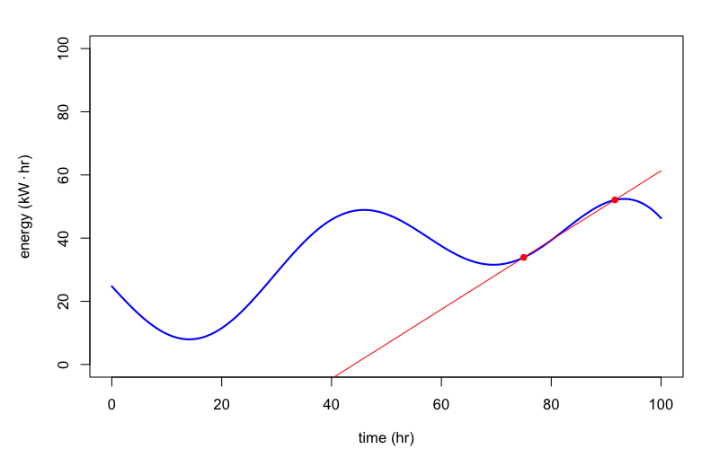

   The two marked points are at coordinates (75, 33.9) and (91.6, 52.1). Determine the average rate of change of the energy over the given interval of time marked by the two points.

   AROC =

#### Question

4. In the table below, various physical quantities and some common units of measure are presented:

   | quantity | units of measure |
   | --- | --- |
   | time | seconds ($\mathrm{s}$) |
   | distance | meters ($\mathrm{m}$) |
   | velocity | meters per second ($\mathrm{m/s}$) |
   | acceleration | meters per squared second ($\mathrm{m/s^2}$) |
   | jerk | meters per cubed second ($\mathrm{m/s^3}$) |
   | force | Newtons ($\mathrm{N}$) |
   | impulse (momentum) | Newton-seconds ($\mathrm{N\cdot s}$) |
   | energy | Newton-meters ($\mathrm{N\cdot m}$) |
   | energy | Joules ($\mathrm{J}$) |
   | energy | kilowatt-hours ($\mathrm{kW\cdot hr}$) |
   | power | Newton-meters per second ($\mathrm{\frac{N\cdot m}{s}}$) |
   | power | Joules per second ($\mathrm{J/s}$) = Watts ($\mathrm{W}$) |
   | power | kilowatt ($\mathrm{kW}$) |
   | electrical charge | Coulombs ($\mathrm{C}$) |
   | electrical current | Coulombs/second ($\mathrm{C/s}$) = amperes ($\mathrm{A}$) |

   A device measures distance (in $\mathrm{m}$) as a function of time (in $\mathrm{s}$). Those measurements are graphed below.

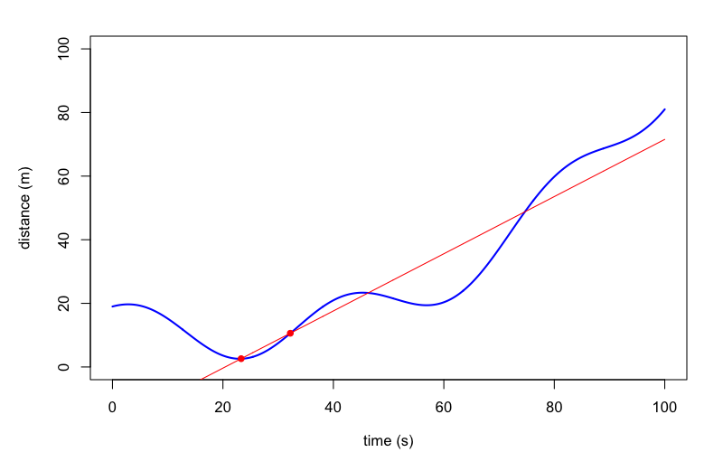

   The two marked points are at coordinates (23.3, 2.6) and (32.2, 10.6). Determine the average rate of change of the distance over the given interval of time marked by the two points.

   AROC =

#### Question

5. In the table below, various physical quantities and some common units of measure are presented:

   | quantity | units of measure |
   | --- | --- |
   | time | seconds ($\mathrm{s}$) |
   | distance | meters ($\mathrm{m}$) |
   | velocity | meters per second ($\mathrm{m/s}$) |
   | acceleration | meters per squared second ($\mathrm{m/s^2}$) |
   | jerk | meters per cubed second ($\mathrm{m/s^3}$) |
   | force | Newtons ($\mathrm{N}$) |
   | impulse (momentum) | Newton-seconds ($\mathrm{N\cdot s}$) |
   | energy | Newton-meters ($\mathrm{N\cdot m}$) |
   | energy | Joules ($\mathrm{J}$) |
   | energy | kilowatt-hours ($\mathrm{kW\cdot hr}$) |
   | power | Newton-meters per second ($\mathrm{\frac{N\cdot m}{s}}$) |
   | power | Joules per second ($\mathrm{J/s}$) = Watts ($\mathrm{W}$) |
   | power | kilowatt ($\mathrm{kW}$) |
   | electrical charge | Coulombs ($\mathrm{C}$) |
   | electrical current | Coulombs/second ($\mathrm{C/s}$) = amperes ($\mathrm{A}$) |

   A device measures distance (in $\mathrm{m}$) as a function of time (in $\mathrm{s}$). Those measurements are graphed below.

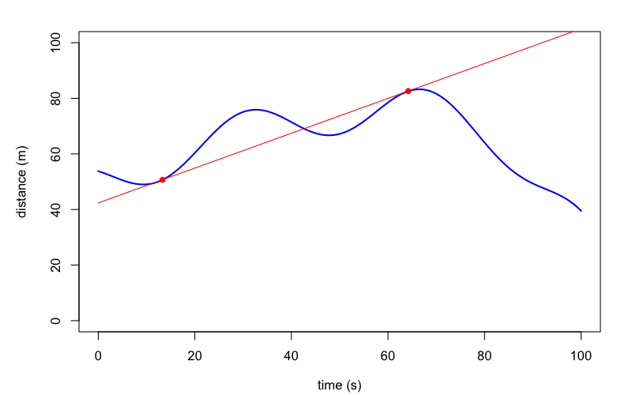

   The two marked points are at coordinates (13.3, 50.7) and (64.2, 82.6). Determine the average rate of change of the distance over the given interval of time marked by the two points.

   AROC =

#### Question

6. In the table below, various physical quantities and some common units of measure are presented:

   | quantity | units of measure |
   | --- | --- |
   | time | seconds ($\mathrm{s}$) |
   | distance | meters ($\mathrm{m}$) |
   | velocity | meters per second ($\mathrm{m/s}$) |
   | acceleration | meters per squared second ($\mathrm{m/s^2}$) |
   | jerk | meters per cubed second ($\mathrm{m/s^3}$) |
   | force | Newtons ($\mathrm{N}$) |
   | impulse (momentum) | Newton-seconds ($\mathrm{N\cdot s}$) |
   | energy | Newton-meters ($\mathrm{N\cdot m}$) |
   | energy | Joules ($\mathrm{J}$) |
   | energy | kilowatt-hours ($\mathrm{kW\cdot hr}$) |
   | power | Newton-meters per second ($\mathrm{\frac{N\cdot m}{s}}$) |
   | power | Joules per second ($\mathrm{J/s}$) = Watts ($\mathrm{W}$) |
   | power | kilowatt ($\mathrm{kW}$) |
   | electrical charge | Coulombs ($\mathrm{C}$) |
   | electrical current | Coulombs/second ($\mathrm{C/s}$) = amperes ($\mathrm{A}$) |

   A device measures distance (in $\mathrm{m}$) as a function of time (in $\mathrm{s}$). Those measurements are graphed below.

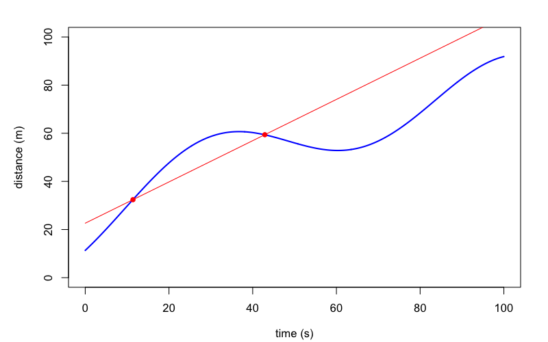

   The two marked points are at coordinates (11.4, 32.4) and (42.9, 59.4). Determine the average rate of change of the distance over the given interval of time marked by the two points.

   AROC =

#### Question

7. In the table below, various physical quantities and some common units of measure are presented:

   | quantity | units of measure |
   | --- | --- |
   | time | seconds ($\mathrm{s}$) |
   | distance | meters ($\mathrm{m}$) |
   | velocity | meters per second ($\mathrm{m/s}$) |
   | acceleration | meters per squared second ($\mathrm{m/s^2}$) |
   | jerk | meters per cubed second ($\mathrm{m/s^3}$) |
   | force | Newtons ($\mathrm{N}$) |
   | impulse (momentum) | Newton-seconds ($\mathrm{N\cdot s}$) |
   | energy | Newton-meters ($\mathrm{N\cdot m}$) |
   | energy | Joules ($\mathrm{J}$) |
   | energy | kilowatt-hours ($\mathrm{kW\cdot hr}$) |
   | power | Newton-meters per second ($\mathrm{\frac{N\cdot m}{s}}$) |
   | power | Joules per second ($\mathrm{J/s}$) = Watts ($\mathrm{W}$) |
   | power | kilowatt ($\mathrm{kW}$) |
   | electrical charge | Coulombs ($\mathrm{C}$) |
   | electrical current | Coulombs/second ($\mathrm{C/s}$) = amperes ($\mathrm{A}$) |

   A device measures velocity (in $\mathrm{m/s}$) as a function of time (in $\mathrm{s}$). Those measurements are graphed below.

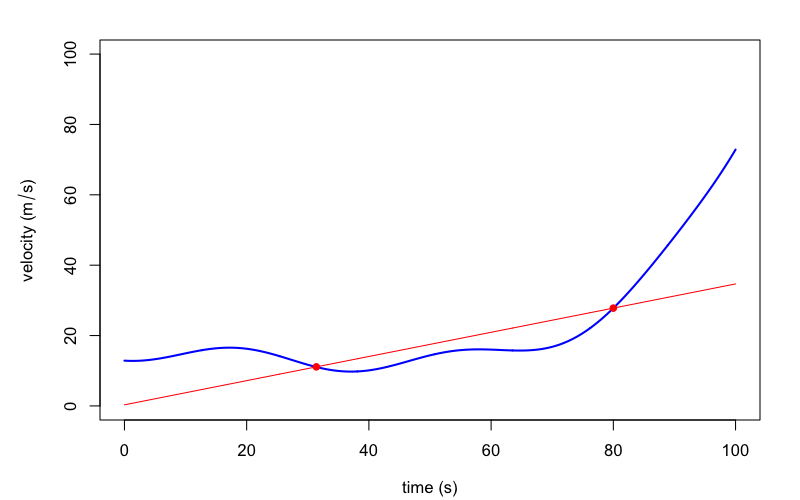

   The two marked points are at coordinates (31.4, 11.1) and (80, 27.8). Determine the average rate of change of the velocity over the given interval of time marked by the two points.

   AROC =

#### Question

8. In the table below, various physical quantities and some common units of measure are presented:

   | quantity | units of measure |
   | --- | --- |
   | time | seconds ($\mathrm{s}$) |
   | distance | meters ($\mathrm{m}$) |
   | velocity | meters per second ($\mathrm{m/s}$) |
   | acceleration | meters per squared second ($\mathrm{m/s^2}$) |
   | jerk | meters per cubed second ($\mathrm{m/s^3}$) |
   | force | Newtons ($\mathrm{N}$) |
   | impulse (momentum) | Newton-seconds ($\mathrm{N\cdot s}$) |
   | energy | Newton-meters ($\mathrm{N\cdot m}$) |
   | energy | Joules ($\mathrm{J}$) |
   | energy | kilowatt-hours ($\mathrm{kW\cdot hr}$) |
   | power | Newton-meters per second ($\mathrm{\frac{N\cdot m}{s}}$) |
   | power | Joules per second ($\mathrm{J/s}$) = Watts ($\mathrm{W}$) |
   | power | kilowatt ($\mathrm{kW}$) |
   | electrical charge | Coulombs ($\mathrm{C}$) |
   | electrical current | Coulombs/second ($\mathrm{C/s}$) = amperes ($\mathrm{A}$) |

   A device measures charge (in $\mathrm{C}$) as a function of time (in $\mathrm{s}$). Those measurements are graphed below.

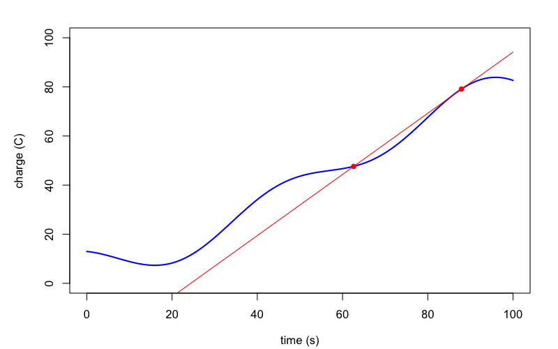

   The two marked points are at coordinates (62.6, 47.6) and (87.9, 79.1). Determine the average rate of change of the charge over the given interval of time marked by the two points.

   AROC =